# Metadata

```
Author: Linnaea Kavulich
Contact: qpk4kp@virginia.edu
Course: DS 5001 (Spring 2023)
```

# The State of Natural Language Processing

### An exploration of the infamous Locke-Hobbes-Rousseau Debate Using NLP techniques

## Load packages for figure display

```python
from IPython.display import Image
import os

os.chdir('C:/Users/linna/Box/MSDS/DS5001/Final Project/Corpus/images/')
```

## I. Introduction

This project aims to explore the works of social contract theorists Thomas Hobbes, Jean-Jacques Rousseau and John Locke in an effort to probe the unique tensions and nuances of their opposing positions. In order to contextualize the work presented, it is necessary to provide a brief summary of the discourse in question. While the motifs of social contract theory date back to the dialogues of Plato, the particular doctrine of which we speak rose to prominence in the middle of the 17$^{th}$ century and remained a hot-button philosophical issue until the mid-19$^{th}$ century (a careful observer may know this period as the Age of Enlightenment). In the most fundamental sense, social contract theory asks how the governing authority justifies its power over the ruled, how civilization comes to exist. It is generally accepted that, in any organized society, citizens must forfeit some degree of personal autonomy in exchange for order, harmony and security -- a mandate which stems from what social contract theorists term 'the state of nature' in reference to the most base condition of human behavior (D’Agostino, 2021).

The shape of a given social contract theory is inherently dependent on the theorist's notion of human nature -- whether human beings are, at our cores, creatures of compassion and justice, or of violence and self-interest. The fate of the political body which successfully supports society depends on an accurate read of the motives and values underpinning human behavior. It is on this point, the essence of human nature, where Hobbes, Locke and Rousseau diverge. For Hobbes, human beings in their natural state (that is, without the imposition of civil authority) were fearful, self-interested, brutish creatures. It follows that, in Hobbes' understanding, society arises from mutual self-interest: a utilitarian truce rooted in a collective desire to preserve our own necks. Rousseau stands in stark opposition to Hobbes, suggesting that the state of nature (in his view, long left behind) was one of tranquility and equality. For Rousseau, the invention of property (the idea that an individual could claim an exclusive right to some finite resource) irrevocably banished this utopian existence. Rousseau's social contract is the modern attempt to artificially impose the blithe harmony of the past through mutual agreement and adherence to the will of the majority. Locke, on the other hand, occupies the liminal space between these two notions. Locke aligns with Rousseau in his conception of the state of nature, seeing it as dominated by peace and mutual assistance, but marks it ultimately as a bygone era. For Locke, the invention of property and the abandonment of our natural state made humans creatures governed mostly by fear, often resorting to violence to defend their claims and person. For this reason, Hobbes and Locke are often situated in opposition to Rousseau. (Laskar, 2013)

This work seeks to examine the debate between Hobbes, Rousseau and Locke, asking chiefly whether this commonly-accepted categorization of each theorist is truly born out in the text.

## II. Source Data

This corpus was obtained from Project Gutenberg. All available works by Hobbes, Locke and Rousseau were included to capture their arguments as accurately as possible.

| Title | Author | Source URL | Format | Box URL |
| --- | --- | --- | --- | --- |
| The Social Contract | Jean-Jacques Rousseau | https://www.gutenberg.org/ebooks/46333 | plaintext | https://virginia.box.com/s/vd98kfw7bjil1ejx8z4euyuyf8ggwfss |
| Leviathan | Thomas Hobbes | https://www.gutenberg.org/ebooks/3207 | plaintext | https://virginia.box.com/s/mbsrflus3gq93ekebkshlbigpuvguaty |
| Second Treatise of Government | John Locke | https://www.gutenberg.org/ebooks/7370 | plaintext | https://virginia.box.com/s/2jdhmo4o62td34xiojm90jh0pu39w5fn |
| Discourse on the Origin and Basis of Inequality Among Men | Jean-Jacques Rousseau | https://www.gutenberg.org/ebooks/11136 | plaintext | https://virginia.box.com/s/976k8neitf41mwaav5sl3o4334xseqvv |
| An Essay Concerning Humane Understanding, Vol. 1 | John Locke | https://www.gutenberg.org/ebooks/10615 | plaintext | https://virginia.box.com/s/vpun69jcpxmb75wrci77up5nyuwh3yo9 |
| An Essay Concerning Humane Understanding, Vol. 2 | John Locke | https://www.gutenberg.org/ebooks/10616 | plaintext | https://virginia.box.com/s/f8aezwai61m17gw4khnmzp2qfyvc4yzj |

**Table 1:** metadata and sourcing information for corpus

As previously discussed, the main concern of this corpus is the works of prominent social contract theorists operating in the Age of Enlightenment. In total, this corpus contains `662,724` observations and has an average document length of `3,621` tokens.

## III. Data Model

| Table Name | Definition | Box URL |
| --- | --- | --- |
| LIB | Metadata for each text | https://virginia.box.com/s/t3rscjlucm5h64psh4hg3ax5jh7s9roe |
| CORPUS | Complete set of tokens | https://virginia.box.com/s/hbejyd7sy3rdnwi5ykla1rcx5c0m9zaj |
| VOCAB | Set of terms included in corpus | https://virginia.box.com/s/aba77aw8ocrk1ufprym4w6vohp91vonz |
| CORPUS_tfidf | TF-IDF added to CORPUS table | https://virginia.box.com/s/pho0v37uqliiazohv1pvrxghxhtd4ugv |
| VOCAB_dfidf | DF-IDF added to VOCAB table | https://virginia.box.com/s/la4eerzwpv474pg1niy5uen3jmcjxk1b |
| LOADINGS | Correlations between DCM terms and PCs | https://virginia.box.com/s/7b4u28otvoahbipfq74weh7vpt4c1ur8 |
| DCM | PC prevalence by document | https://virginia.box.com/s/vvug747bfsn9bgt65w1gyxaxahsbz4re |
| TOPICS | Topics and term counts from LDA by author | https://virginia.box.com/s/ucj4ctab5cz6f2tsubrlio3r8zfm97yt |
| THETA | Topic distribution by document | https://virginia.box.com/s/0y14xg8kyvhntg5jsnadjoekl2vj8uxf |
| PHI | Probability distribution of terms for each topic | https://virginia.box.com/s/csuklq7t66ogmg2xpqzj7xop5c98s3mm |
| W2V | Terms and embeddings | https://virginia.box.com/s/urg9megrgqptyxoi76tmtotc23vg2m4n |
| SENTIMENT | Sentiment and emotion values as features in VOCAB | https://virginia.box.com/s/5ve0h150o3fge06i9t9z30wbp4ydrgf6 |
| DOC_EMO | Sentiment polarity/emotions by document | https://virginia.box.com/s/dn6f1y22qrqnv75uzcwucxmzyuh4pau3 |

**Table 2:** description and location of analytical tables

First, the six texts included in this corpus were parsed and tokenized. Metadata regarding each text (including the number of chapters and tokens) was saved in a LIB table. The ordered hierarchy of content objects (OHCO) utilized in tokenization went: book, chapter, paragraph, sentence and token, in line with the pattern commonly used when analyzing novels. A complete table of tokens representing the contents of the corpus was saved as the `CORPUS` table. All numeric and symbolic terms were removed from the `CORPUS`. The `VOCAB` table was then generated by simply aggregating appearances of each unique token within the `CORPUS`. `VOCAB` was annotated with the probability that a given token would appear in the `CORPUS` (p), the entropy, or uncertainty surrounding the appearance of a term (h), the information content (i) which can be thought of as the degree of surprise associated with a term's appearance, the part of speech (max_pos) represented by each term, whether a term represented a stop word (stop), and several different methods of extracting the stem of each term. Before moving to more advanced exploratory techniques, the Term Frequency-Inverse Document Frequency (TF-IDF) and Document Frequency-Inverse Document Frequency (DF-IDF) were computed and appended to the `CORPUS` and `VOCAB` tables, respectively.

In the process of principal component analysis (PCA), the top 10 principal components were assessed, using chapter as the document level which allowed sufficient granularity within each work. The results of this work will be discussed in a later section, here we simply note the resulting `LOADINGS` and `DCM` tables, which contain the correlation coefficients between the terms and the top 10 principal components, and the weighted scores of each principal component in each document, respectively.

Latent dirichlet allocation (LDA), or topic modeling, produced the `PHI` (topic and term counts) and `THETA` (each row represents a document, each column a topic) tables which were combined to create the `TOPICS` table. Obtaining word embeddings yielded the `W2V` table, containing terms and their respective embeddings. Finally, sentiment analysis produced the `SENTIMENT` (aligns sentiment and emotion values as features in `VOCAB`) and `DOC_EMO` (shows the sentiment polarity and emotion by document) tables.

## IV. Exploration

### Principal Components (PCA)

Principal component analysis was useful in visualizing the ways in which Hobbes, Rousseau and Locke were positioned in relation to one another -- truly getting at the heart of this inquiry. For these purposes, it was worthwhile to examine the ways in which clusters appeared, both when grouping by author and by individual text. If there are indeed significant differences in each theorist's beliefs, any clusters apparent when grouping by author ougth to persist at the level of individual texts. Moreover, if the generally accepted divergence between the two schools of thought is to hold, Rousseaus' work should be markedly distinct from that of Hobbes and Locke, whose texts should exhibit significant overlap.

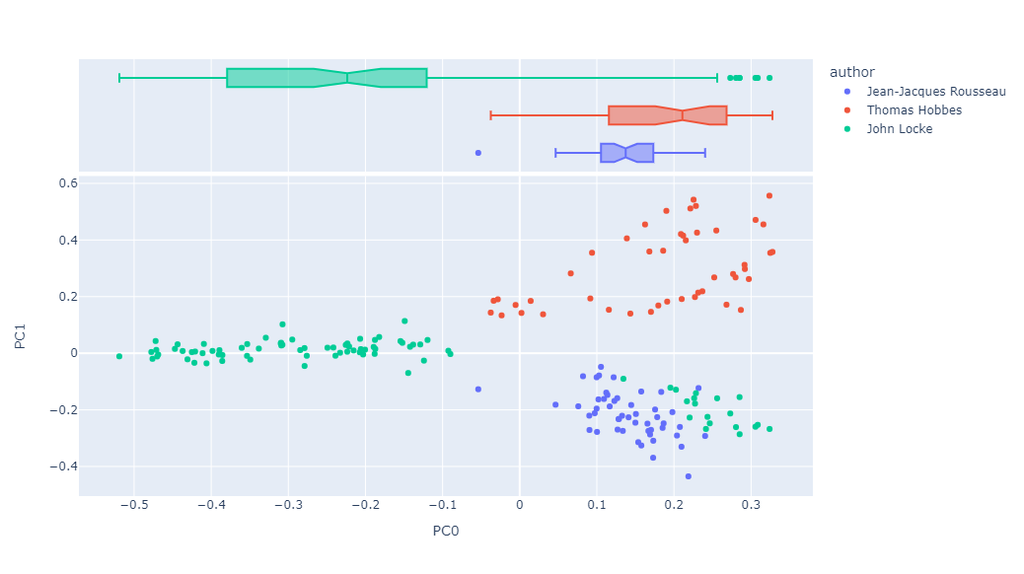

```python
display(Image(filename='fig1.png'))
```

```
Figure 1: distribution of works of Hobbes, Rousseau and Locke (bagging by chapter) across principal components 0 and 1.
```

At first glance, the distribution of Hobbes, Rousseau and Locke's works appears misaligned with the scholarly consensus (Fig. 1). Most notable is the overlap between Rousseau and Locke, but it is important to bear in mind that these works span a vast array of questions, and alignment on one set of issues should not be overinterpreted.

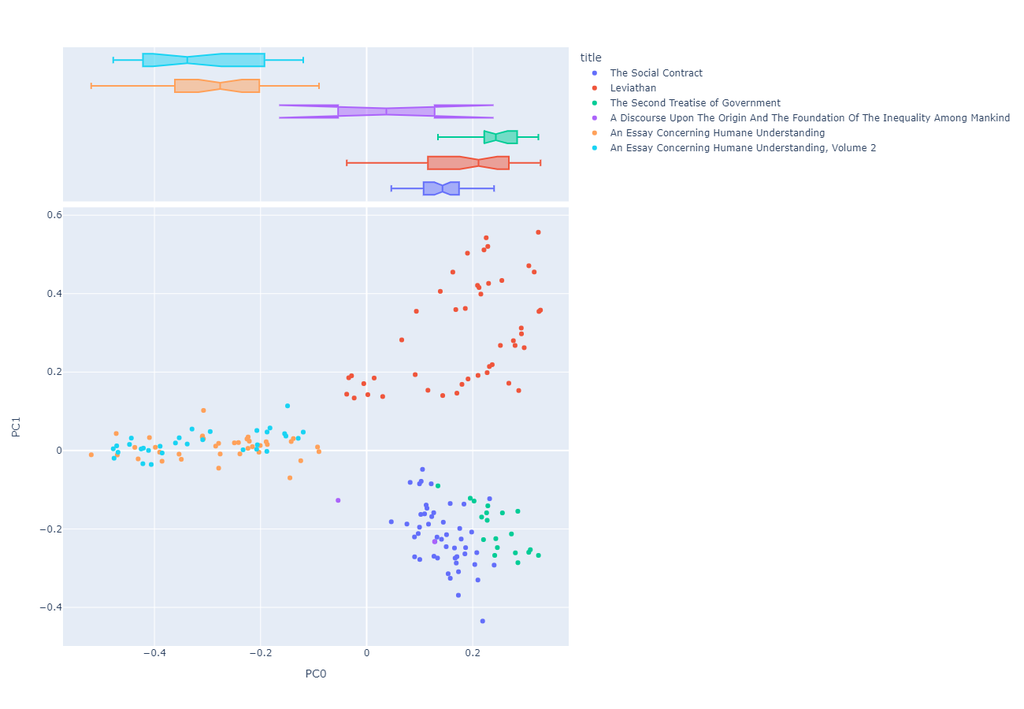

```python
display(Image(filename='fig2.png'))
```

```
Figure 2: distribution of works of Hobbes, Rousseau and Locke (bagging by chapter) across principal components 0 and 1
```

Hobbes and Rousseau seem more aligned with respect to PC0, which is positively associated with terms including 'government', 'commonwealth' and 'law'. In contrast, Locke's works seem evenly dispersed across PC0, with a notable cluster towards the negative values, associated with terms like 'idea', 'mind', and 'knowledge'. PC1 seems responsible for dividing Hobbes, Locke and Rousseau most dramatically, with the negative end of the span representing terms like 'government' and 'state' while the positive end includes 'god', 'kingdome' and 'christ' -- suggesting Hobbes perhaps more interested in engaging the idea of divine right than his counterparts.

It is important to mention that these plots were generated by first filtering the `COURPUS` such that only the top 1000 terms with a `max_pos` tag in the list `'NN', 'VB', 'JJ'`, in order to ensure imformative results. Works were bagged by chapter and covariance was computed off of `L2 TFIDF`.

### Topic Models (LDA)

To further investigate the themes, arguments and convictions most important to each respective thinker, LDA was employed.

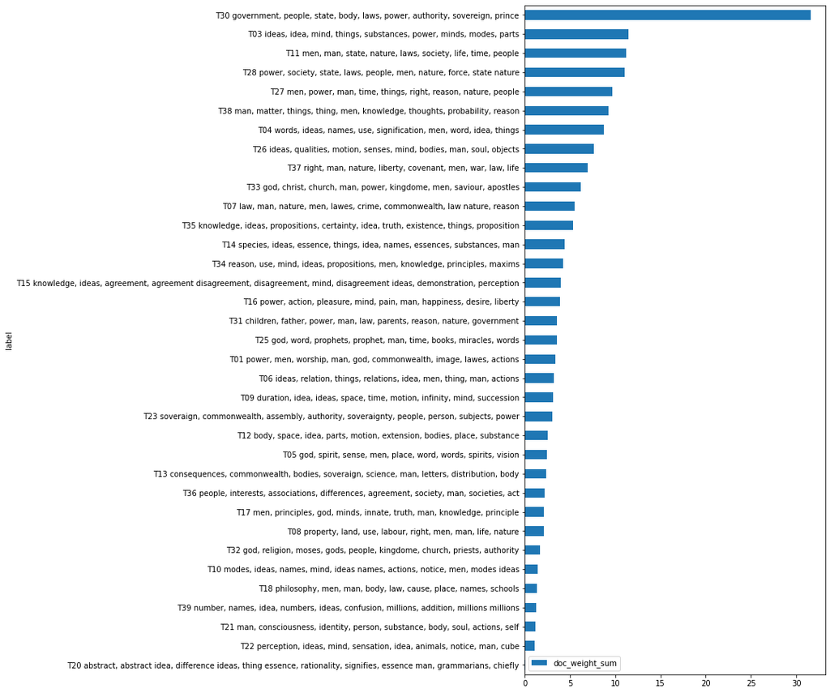

```python
display(Image(filename='fig3.png'))
```

[output not shown]

More central to our question, however, is the representation of topics amongs authors.

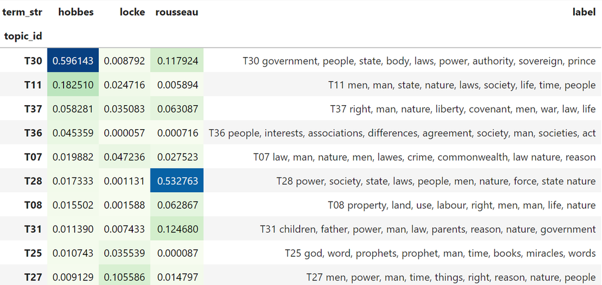

```python
display(Image(filename='fig5.png'))
```

```
Figure 4: topic prevalence sorted by representation in Hobbes' text
```

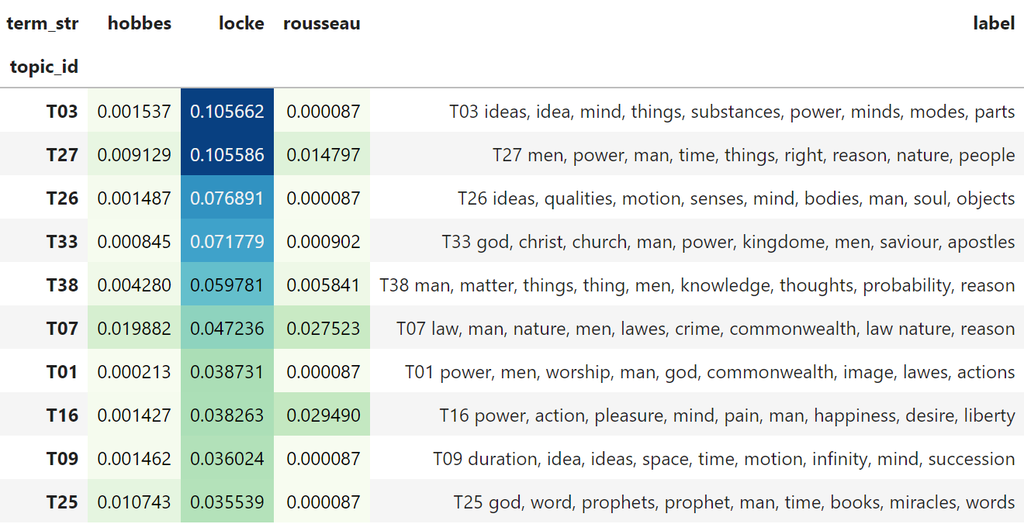

```python
display(Image(filename='fig6.png'))
```

```
Figure 5: topic prevalence sorted by representation in Locke's texts
```

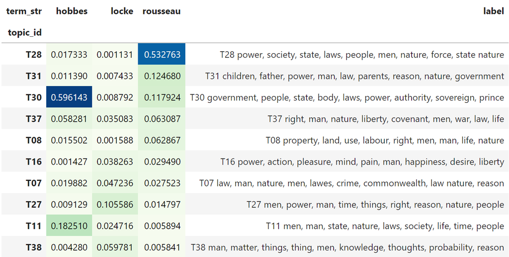

```python
display(Image(filename='fig7.png'))
```

```
Figure 6: topic prevalence sorted by representation in Rousseau's texts
```

### Word Embeddings

Word embeddings may help shine light on associations between terms which were not originally apparent. To generate the following plots, the parameters used were `window = 10`, `min_count = 50`, and `workers = 4`.

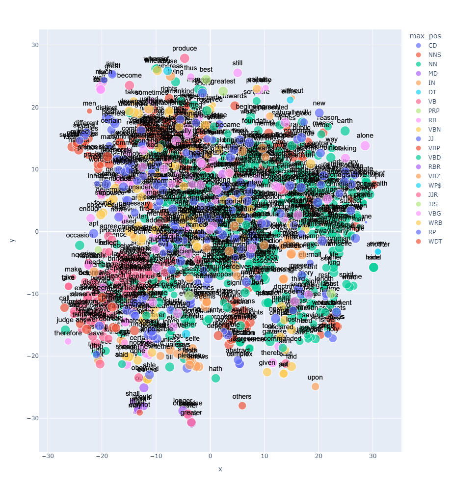

```python
display(Image(filename='fig8.png'))
```

```
Figure 7: word embeddings
```

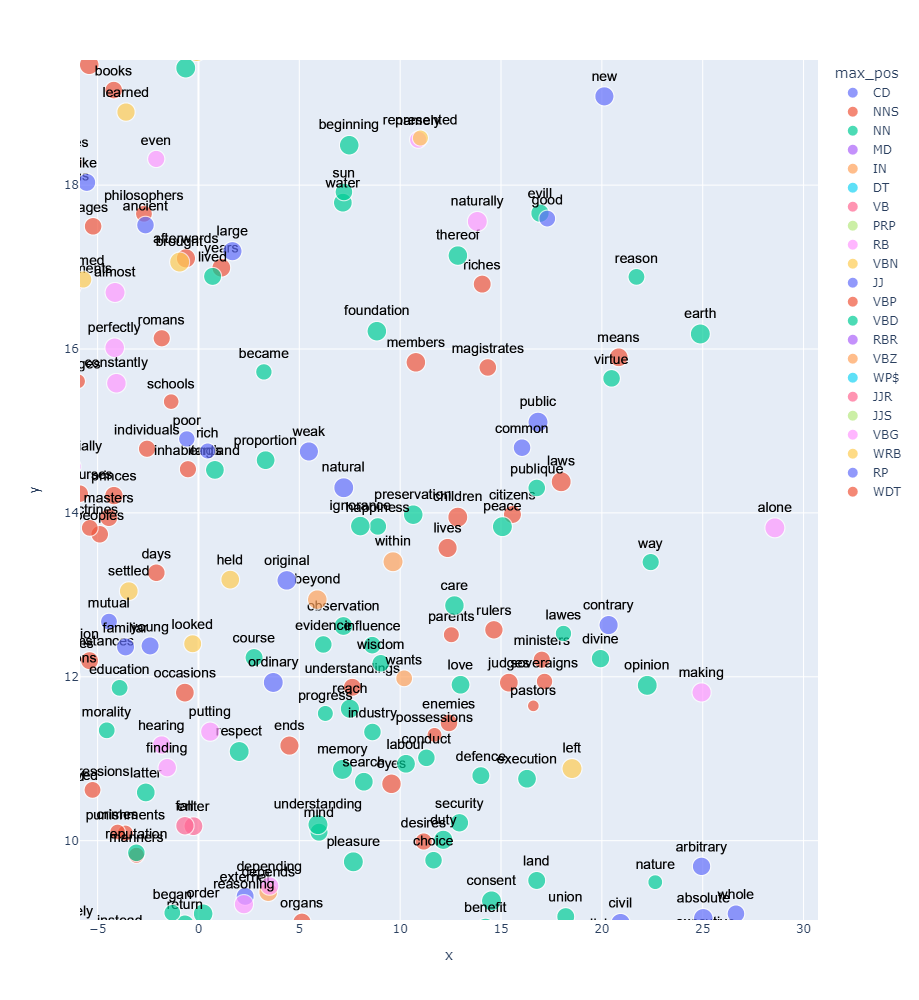

```python
display(Image(filename='fig9.png'))
```

```
Figure 8: close-up of word embeddings
```

While some interesting clusters surely exist in the above plots (Figures 7, 8) this metric admittedly does not permit the direct comparison of authors. One brief aside that warrants mention is the proximity of the words 'enemies' and 'possessions' as it calls to mind the villain that Rousseau and Locke blame for disrupting mankinds' 'natural state' of harmony.

### Sentiment Analysis

Sentiment analysis was performed using the NRC Sentiment Analysis Lexicon, which is best suited to modern English; the insights obtained were nevertheless instructive.

Briefly returning to Fig. 2, it appears that Locke's Discourses on Humane Understanding may be the root of his marked divergence from Hobbes and Rousseau. It was subsequently helpful to examine sentiment on a text-by-text basis. Looking below (Fig. 9), it almost appears that Hobbes, not Locke, is the writer seeking to distance himself from the field. Unsurprisingly, Leviathan scores the highest out of all works in the 'fear' category. It is also notable that only two works possess negative values for sentiment: one by Locke and one by Rousseau.

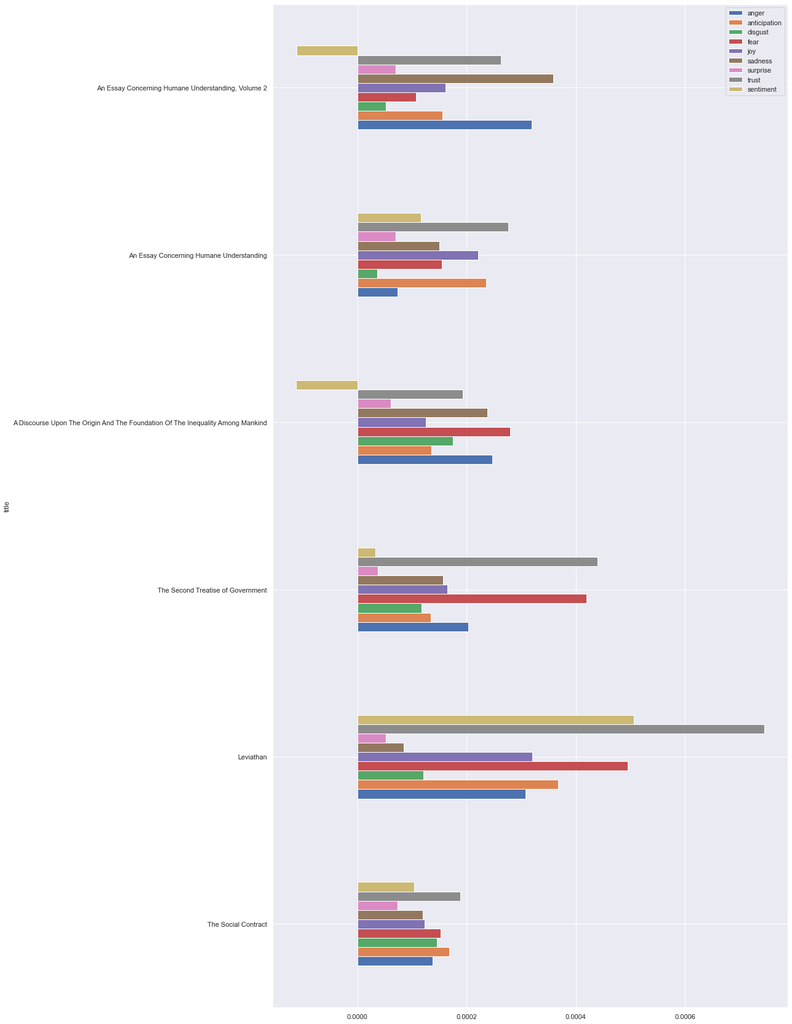

```python
display(Image(filename='fig10.png'))
```

```
Figure 9: sentiment analysis by text.
```

Moving then, to a more holistic view of sentiment, we probe the more general valence of Hobbes, Rousseau and Locke's works. Locke and Hobbes' dominating sentiment is trust (Figures 10, 12) while Rousseau's works prove more balanced. Locke scores the lowest in terms of fear, but ultimately the three theorists are relatively similar across sentiments.

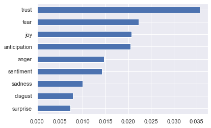

```python
display(Image(filename='fig11.png'))
```

```
Figure 10: sentiment analysis for the works of Thomas Hobbes
```

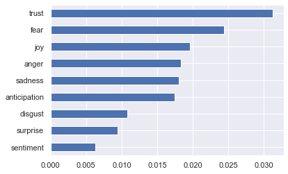

```python
display(Image(filename='fig12.png'))
```

```
Figure 11: sentiment analysis for the works of Jean-Jacques Rousseau
```

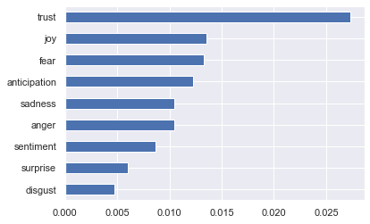

```python
display(Image(filename='fig13.png'))
```

```
Figure 12: sentiment analysis for the works of John Locke
```

## V. Interpretation

Now, it must be mentioned that this corpus could certainly be expanded, particularly in the case of Hobbes. Re-running these analyses with some lesser-known (and harder to find) texts might illuminate new avenues of inquiry. Potential future work could include more contemporary responses to social contract theory (thinkers like Kant, Rawls and Pettit), cataloging the evolution of our conception of humankind and the social world that binds us.

## References

```
D’Agostino, F., et al., "Contemporary Approaches to the Social Contract", The Stanford Encyclopedia of Philosophy. (Winter 2021 Edition). https://plato.stanford.edu/archives/win2021/entries/contractarianism-contemporary

Laskar, M. Summary of Social Contract Theory by Hobbes, Locke and Rousseau. (April 4, 2013). http://dx.doi.org/10.2139/ssrn.2410525

Hobbes, T. (2008). Leviathan (J. C. A. Gaskin, Ed.). Oxford University Press.Hobbes, T. (2008). Leviathan (J. C. A. Gaskin, Ed.). Oxford University Press.

Rousseau, J.J. (2004). The social contract. Penguin Books.

Locke, J. (1980). Second treatise of government (C. B. Macpherson, Ed.). Hackett Publishing.Locke, J. (1980). Second treatise of government (C. B. Macpherson, Ed.). Hackett Publishing.
```